#### 21.11.23, © Kudryavets Yehor KI-21-1, 2023

# Лабораторна робота №4. Робота з OpenCV у середовищі Anaconda

**Мета:** quick start для роботи з бібліотекою з відкритим кодом для комп’ютерного зору та обробки зображень OpenCV у середовищі Anaconda із застосуванням Jupyter Notebook засобами мови програмування Python.

# Хід роботи

1.Завантажити і встановити збірку Python Anaconda.

2.Через інтерфейс командного рядка налаштувати за допомогою conda віртуальне середовище з ім’ям _OpenCV. Етапи роботи підтвердити скріншотами.

[figure not shown]

3.Проінсталювати в створене середовище пакети, необхідні для роботи з OpenCV.

[figure not shown]

4.Сфотографувати "себе" на камеру і виконати імпорт і візуалізацію кольорового та напівтонового зображення у робочий документ.

```python
import numpy as np
import cv2 as cv
import matplotlib.pyplot as plt

def display_opencv_version():
    print('OpenCV Version: %s' % cv.__version__)

display_opencv_version()
```

```
OpenCV Version: 4.8.1
```

```python
import cv2 as cv

def process_image(image_path):
    image = cv.imread(image_path)
    print(f'Dimensions: {image.shape}')
    print(f'Pixel count: {image.size}')

image_path = 'img/Nature.jpg'

process_image(image_path)
```

```
Dimensions: (641, 1140, 3)
Pixel count: 2192220
```

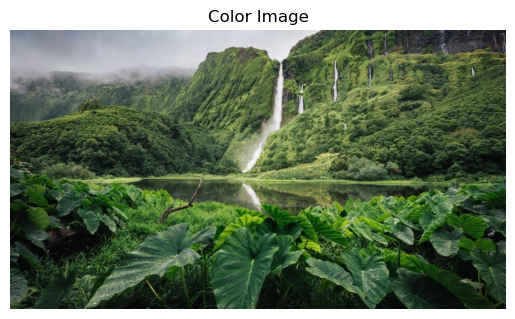

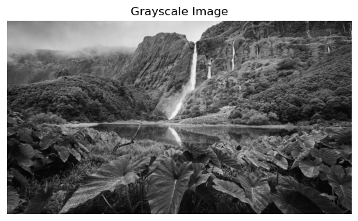

```python
import cv2 as cv
from IPython.display import display, Image
import matplotlib.pyplot as plt

def show_images(color_img, grayscale_img):
    color_img_rgb = cv.cvtColor(color_img, cv.COLOR_BGR2RGB)

    plt.imshow(color_img_rgb)
    plt.title('Color Image')
    plt.axis('off')
    plt.show()

    plt.imshow(grayscale_img, cmap='gray')
    plt.title('Grayscale Image')
    plt.axis('off')
    plt.show()

color_img_path = 'img/Nature.jpg'
grayscale_img_path = 'img/Nature.jpg'

color_img = cv.imread(color_img_path)
grayscale_img = cv.imread(grayscale_img_path, cv.IMREAD_GRAYSCALE)

show_images(color_img, grayscale_img)
```

5.Виконати переведення кольорового зображення у напівтонове і записати його на диск.

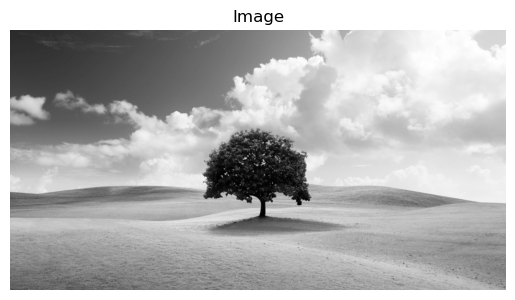

```
Grayscale image saved.
```

```python
import matplotlib.pyplot as plt
import cv2

def load_and_show_image(image_path):
    image = cv2.imread(image_path, cv2.IMREAD_GRAYSCALE)

    if image is not None:
        plt.imshow(image, cmap='gray')
        plt.title('Image')
        plt.axis('off')
        plt.show()
    else:
        print('Failed to load the image.')

    return image

image_path = 'img/Nature-free.jpg'

loaded_image = load_and_show_image(image_path)

if loaded_image is not None:
    cv2.imwrite('img/Nature-free_grayscale.jpg', loaded_image)
    print('Grayscale image saved.')
```

## Контрольні запитання

1.Що таке pip і conda та чим вони відрізняються між собою?

`pip` (Python Package Installer) - це стандартний інструмент управління пакетами для Python. Він призначений для інсталяції, оновлення та видалення пакетів Python. `pip` дозволяє легко встановлювати сторонні бібліотеки та інші компоненти, необхідні для роботи з Python. `conda` дозволяє інсталювати, оновлювати, видаляти та керувати пакетами для різних мов програмування, включаючи Python. Він має свій власний репозиторій пакетів, який включає в себе багато популярних бібліотек. Основна різниця між `pip` і `conda` полягає в тому, що `pip` призначений для управління пакетами Python і працює з PyPI, тоді як `cond`a - це більш загальний інструмент, який може використовуватися для управління пакетами різних мов програмування та має власний репозиторій пакетів. conda також надає інструменти для створення і управління віртуальними середовищами Python, що робить його зручним для ізоляції середовищ та управління залежностями.

2.Як буде виглядати виконання пунктів 1-3 індивідуального завдання за допомогою Virtualenv?

[figure not shown]

3.Як виконати візуалізацію зображення засобами mathplotlib?

Для візуалізації зображення засобами бібліотеки Matplotlib, використовується функція `imshow`. `imshow` - це функція з бібліотеки Matplotlib, яка використовується для візуалізації зображень. Вона дозволяє відображати зображення в графічному вікні, що надається Matplotlib.

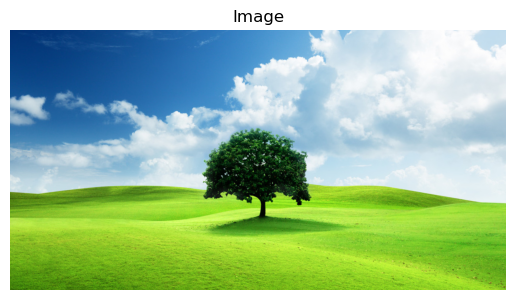

```python
import matplotlib.pyplot as plt
import cv2

def show_image(image_path):
    img = cv2.imread(image_path)
    img_rgb = cv2.cvtColor(img, cv2.COLOR_BGR2RGB)

    plt.imshow(img_rgb)
    plt.title('Image')
    plt.axis('off')
    plt.show()

image_path = 'img/Nature-free.jpg'

show_image(image_path)
```

4.Як виконати компіляцію вхідного документа Jupyter Notebook із його середовища , не використовуючи інтерфейс командного рядка?

[figure not shown]

## References

1.https://github.com/wtfpanda007/Python - посилання на GitHub-репозиторій